# STACC Test - Task 2

Enlik Tjioe

2/10/2020

# Introduction

The dataset is SP500 stock index and different variables that show the current business climate from year 2000 to 2014. The goal of this analysis is to create Machine Learning model to predict `label` variable for the year 2015.

- label = 1 means, that product should be in the market
- label = 0 means, that product should be out of market

# Library

```r
library(tidyverse)
library(lubridate)

options(scipen = 9999)
```

## Data Pre-processing

```r
marketData <- read.csv("market_test_data.csv")
marketData$date <- dmy(marketData$date) # change data type of variable "date" from factor to Date
marketData <- select(marketData, -c("SP500")) # remove "SP500" variable
glimpse(marketData)
```

```
## Observations: 192
## Variables: 18
## $ date               <date> 2000-01-24, 2000-02-24, 2000-03-24, 2000-04-…
## $ usman.50           <int> 1, 1, 1, 1, 1, 1, 0, 0, 0, 0, 0, 0, 0, 0, 0, …
## $ glocom.50          <int> 1, 1, 1, 1, 1, 1, 0, 0, 0, 0, 0, 0, 0, 0, 0, …
## $ usman.40           <int> 1, 1, 1, 1, 1, 1, 1, 1, 1, 1, 1, 1, 1, 1, 1, …
## $ glocom.40          <int> 1, 1, 1, 1, 1, 1, 1, 1, 1, 1, 1, 1, 1, 1, 1, …
## $ usman.growing      <int> 0, 0, 0, 0, 0, 1, 0, 0, 0, 0, 0, 0, 0, 1, 0, …
## $ glocom.growing     <int> 0, 0, 0, 0, 0, 1, 0, 0, 0, 0, 0, 0, 0, 1, 0, …
## $ usman.accel        <int> 0, 0, 0, 0, 0, 0, 0, 0, 0, 0, 0, 0, 0, 0, 0, …
## $ glocom.accel       <int> 0, 0, 0, 0, 0, 0, 0, 0, 0, 0, 0, 0, 0, 0, 0, …
## $ usman.3mgrowth     <int> 0, 0, 0, 0, 0, 0, 0, 0, 0, 0, 0, 0, 0, 0, 0, …
## $ glocom.3mgrowth    <int> 0, 0, 0, 0, 0, 0, 0, 0, 0, 0, 0, 0, 0, 0, 0, …
## $ profitgrowth.pos   <int> 1, 1, 1, 1, 1, 1, 1, 1, 1, 1, 1, 1, 0, 0, 0, …
## $ revgrowth.pos      <int> 1, 1, 1, 1, 1, 1, 1, 1, 1, 1, 1, 1, 1, 1, 1, …
## $ profitgrowth.accel <int> 1, 1, 1, 0, 0, 0, 0, 0, 0, 0, 0, 0, 0, 0, 0, …
## $ revgrowth.accel    <int> 1, 1, 1, 0, 0, 0, 0, 0, 0, 0, 0, 0, 0, 0, 0, …
## $ industry.growing   <int> 1, 1, 1, 1, 1, 1, 1, 1, 1, 1, 1, 1, 1, 1, 0, …
## $ industry.accel     <int> 1, 0, 0, 1, 1, 0, 1, 0, 0, 1, 0, 0, 0, 0, 0, …
## $ label              <int> 1, 1, 1, 1, 1, 1, 0, 0, 0, 0, 0, 0, 0, 0, 0, …
```

## Filter data to include only rows from year before 2015

```r
before2015 <- marketData %>%
  filter(year(marketData$date) < 2015) %>% # filter data only for date before year 2015
  select(-c("date")) # remove column "date"
glimpse(before2015)
```

```
## Observations: 180
## Variables: 17
## $ usman.50           <int> 1, 1, 1, 1, 1, 1, 0, 0, 0, 0, 0, 0, 0, 0, 0, …
## $ glocom.50          <int> 1, 1, 1, 1, 1, 1, 0, 0, 0, 0, 0, 0, 0, 0, 0, …
## $ usman.40           <int> 1, 1, 1, 1, 1, 1, 1, 1, 1, 1, 1, 1, 1, 1, 1, …
## $ glocom.40          <int> 1, 1, 1, 1, 1, 1, 1, 1, 1, 1, 1, 1, 1, 1, 1, …
## $ usman.growing      <int> 0, 0, 0, 0, 0, 1, 0, 0, 0, 0, 0, 0, 0, 1, 0, …
## $ glocom.growing     <int> 0, 0, 0, 0, 0, 1, 0, 0, 0, 0, 0, 0, 0, 1, 0, …
## $ usman.accel        <int> 0, 0, 0, 0, 0, 0, 0, 0, 0, 0, 0, 0, 0, 0, 0, …
## $ glocom.accel       <int> 0, 0, 0, 0, 0, 0, 0, 0, 0, 0, 0, 0, 0, 0, 0, …
## $ usman.3mgrowth     <int> 0, 0, 0, 0, 0, 0, 0, 0, 0, 0, 0, 0, 0, 0, 0, …
## $ glocom.3mgrowth    <int> 0, 0, 0, 0, 0, 0, 0, 0, 0, 0, 0, 0, 0, 0, 0, …
## $ profitgrowth.pos   <int> 1, 1, 1, 1, 1, 1, 1, 1, 1, 1, 1, 1, 0, 0, 0, …
## $ revgrowth.pos      <int> 1, 1, 1, 1, 1, 1, 1, 1, 1, 1, 1, 1, 1, 1, 1, …
## $ profitgrowth.accel <int> 1, 1, 1, 0, 0, 0, 0, 0, 0, 0, 0, 0, 0, 0, 0, …
## $ revgrowth.accel    <int> 1, 1, 1, 0, 0, 0, 0, 0, 0, 0, 0, 0, 0, 0, 0, …
## $ industry.growing   <int> 1, 1, 1, 1, 1, 1, 1, 1, 1, 1, 1, 1, 1, 1, 0, …
## $ industry.accel     <int> 1, 0, 0, 1, 1, 0, 1, 0, 0, 1, 0, 0, 0, 0, 0, …
## $ label              <int> 1, 1, 1, 1, 1, 1, 0, 0, 0, 0, 0, 0, 0, 0, 0, …
```

## Split data train and test for our Machine Learning model

```r
set.seed(123)
intrain <- sample(nrow(before2015), nrow(before2015)*0.8)
before2015.train <- before2015[intrain, ]
before2015.test <- before2015[-intrain, ]
```

## Creating Logistic Regression model as our first model

```r
model1.lr <- glm(label ~ ., data = before2015.train, family = "binomial") # create model with all predictors
summary(model1.lr)
```

```
##
## Call:
## glm(formula = label ~ ., family = "binomial", data = before2015.train)
##
## Deviance Residuals:
##      Min        1Q    Median        3Q       Max
## -2.56563   0.00015   0.23460   0.31789   1.98007
##
## Coefficients: (1 not defined because of singularities)
##                     Estimate Std. Error z value Pr(>|z|)
## (Intercept)          -1.9917     1.4880  -1.339    0.181
## usman.50            -15.3209  1878.3192  -0.008    0.993
## glocom.50            18.7018  1878.3191   0.010    0.992
## usman.40             -2.1907     1.4754  -1.485    0.138
## glocom.40                 NA         NA      NA       NA
## usman.growing         0.4120     1.4994   0.275    0.783
## glocom.growing       -0.3638     1.4633  -0.249    0.804
## usman.accel           1.7257     3.8223   0.451    0.652
## glocom.accel         -3.4325     3.9544  -0.868    0.385
## usman.3mgrowth        1.5417     3.6797   0.419    0.675
## glocom.3mgrowth       3.1099     3.8570   0.806    0.420
## profitgrowth.pos      2.0585     0.9246   2.226    0.026 *
## revgrowth.pos         0.6171     0.8931   0.691    0.490
## profitgrowth.accel   -0.6192     0.8316  -0.745    0.457
## revgrowth.accel       0.2033     0.7462   0.273    0.785
## industry.growing      1.7308     1.1934   1.450    0.147
## industry.accel       -0.2291     0.6986  -0.328    0.743
## ---
## Signif. codes:  0 '***' 0.001 '**' 0.01 '*' 0.05 '.' 0.1 ' ' 1
##
## (Dispersion parameter for binomial family taken to be 1)
##
##     Null deviance: 159.718  on 143  degrees of freedom
## Residual deviance:  74.761  on 128  degrees of freedom
## AIC: 106.76
##
## Number of Fisher Scoring iterations: 16
```

From our logistic regression model summary above, we found out that variable `glocom.40` shows NA value. It means that this variable has very high correlation with other variable which is `usman.40`. Removing one of them will solve the problem [Reference](https://stats.stackexchange.com/questions/212903/na-in-glm-model)

## Removing `glocom.40` variable in our model

`glm()` function is used to construct our binomial Logistic Regression model in R

```r
model1.lr <- glm(label ~ . - glocom.40, data = before2015.train, family = "binomial")
summary(model1.lr)
```

```
##
## Call:
## glm(formula = label ~ . - glocom.40, family = "binomial", data = before2015.train)
##
## Deviance Residuals:
##      Min        1Q    Median        3Q       Max
## -2.56563   0.00015   0.23460   0.31789   1.98007
##
## Coefficients:
##                     Estimate Std. Error z value Pr(>|z|)
## (Intercept)          -1.9917     1.4880  -1.339    0.181
## usman.50            -15.3209  1878.3192  -0.008    0.993
## glocom.50            18.7018  1878.3191   0.010    0.992
## usman.40             -2.1907     1.4754  -1.485    0.138
## usman.growing         0.4120     1.4994   0.275    0.783
## glocom.growing       -0.3638     1.4633  -0.249    0.804
## usman.accel           1.7257     3.8223   0.451    0.652
## glocom.accel         -3.4325     3.9544  -0.868    0.385
## usman.3mgrowth        1.5417     3.6797   0.419    0.675
## glocom.3mgrowth       3.1099     3.8570   0.806    0.420
## profitgrowth.pos      2.0585     0.9246   2.226    0.026 *
## revgrowth.pos         0.6171     0.8931   0.691    0.490
## profitgrowth.accel   -0.6192     0.8316  -0.745    0.457
## revgrowth.accel       0.2033     0.7462   0.273    0.785
## industry.growing      1.7308     1.1934   1.450    0.147
## industry.accel       -0.2291     0.6986  -0.328    0.743
## ---
## Signif. codes:  0 '***' 0.001 '**' 0.01 '*' 0.05 '.' 0.1 ' ' 1
##
## (Dispersion parameter for binomial family taken to be 1)
##
##     Null deviance: 159.718  on 143  degrees of freedom
## Residual deviance:  74.761  on 128  degrees of freedom
## AIC: 106.76
##
## Number of Fisher Scoring iterations: 16
```

## Create the new variable `pred.label` for test dataset

Using `predict()` function specifying the:

- Model to be used for prediction (`model1.lr`)
- Dataset on which the model should predict (`before2015.test`) with a `response` type, in order to make the prediction based on the scale of the response variable (which means: `probabilities`).

```r
before2015.test$pred.label <- predict(model1.lr, before2015.test, type = "response")
glimpse(before2015.test)
```

```
## Observations: 36
## Variables: 18
## $ usman.50           <int> 1, 1, 0, 0, 0, 0, 1, 0, 1, 1, 1, 1, 1, 1, 1, …
## $ glocom.50          <int> 1, 1, 0, 0, 0, 0, 1, 0, 1, 1, 1, 1, 1, 1, 1, …
## $ usman.40           <int> 1, 1, 1, 1, 1, 1, 1, 1, 1, 1, 1, 1, 1, 1, 1, …
## $ glocom.40          <int> 1, 1, 1, 1, 1, 1, 1, 1, 1, 1, 1, 1, 1, 1, 1, …
## $ usman.growing      <int> 0, 0, 1, 0, 1, 1, 1, 0, 1, 1, 1, 0, 0, 0, 0, …
## $ glocom.growing     <int> 0, 0, 1, 0, 1, 1, 1, 0, 1, 1, 1, 0, 0, 0, 0, …
## $ usman.accel        <int> 0, 0, 0, 0, 0, 0, 0, 0, 1, 0, 0, 0, 0, 0, 0, …
## $ glocom.accel       <int> 0, 0, 0, 0, 0, 0, 0, 0, 1, 0, 0, 0, 0, 0, 0, …
## $ usman.3mgrowth     <int> 0, 0, 0, 0, 0, 0, 0, 0, 0, 1, 0, 0, 0, 0, 0, …
## $ glocom.3mgrowth    <int> 0, 0, 0, 0, 0, 0, 0, 0, 0, 1, 0, 0, 0, 0, 0, …
## $ profitgrowth.pos   <int> 1, 1, 0, 0, 0, 0, 1, 1, 1, 1, 1, 1, 1, 1, 1, …
## $ revgrowth.pos      <int> 1, 1, 1, 1, 1, 0, 0, 0, 1, 1, 1, 1, 1, 1, 1, …
## $ profitgrowth.accel <int> 1, 1, 0, 0, 0, 1, 1, 0, 0, 1, 1, 1, 1, 0, 1, …
## $ revgrowth.accel    <int> 1, 1, 0, 0, 0, 0, 0, 0, 1, 1, 0, 1, 0, 1, 1, …
## $ industry.growing   <int> 1, 1, 1, 0, 0, 0, 0, 1, 0, 1, 1, 1, 1, 1, 1, …
## $ industry.accel     <int> 0, 0, 0, 0, 0, 0, 1, 1, 0, 1, 0, 1, 1, 0, 1, …
## $ label              <int> 1, 1, 0, 0, 0, 0, 0, 1, 1, 1, 1, 1, 1, 1, 1, …
## $ pred.label         <dbl> 0.960419188, 0.960419188, 0.143535533, 0.0275…
```

Visualize the distribution of probabilities of a label default from our prediction vector:

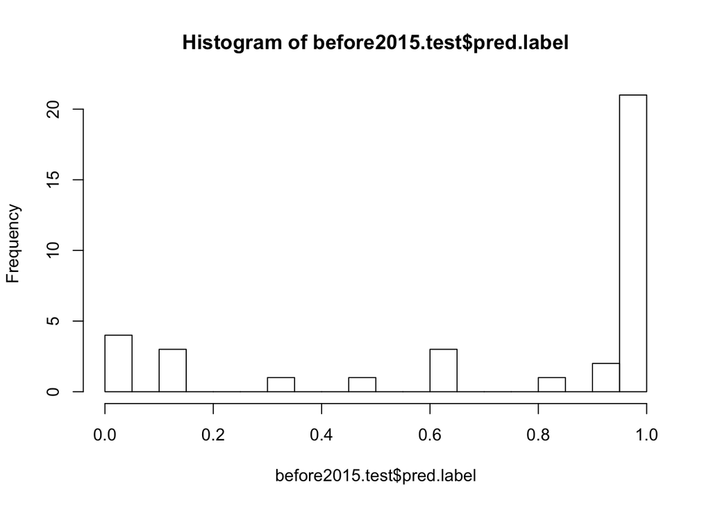

```r
hist(before2015.test$pred.label, breaks=20)
```

## Create Confusion Matrix table

For the first try, we setup our `label` threshold at 0.5 which means will predict any labels that exceed that threshold as `label = 1`. Threshold 0.5 may not always be the right threshold setting and we’ll try to change it later

```r
table("predicted"=as.numeric(before2015.test$pred.label>=0.5), "actual"=before2015.test$label)
```

```
##          actual
## predicted  0  1
##         0  7  2
##         1  1 26
```

Observe from the confusion matrix that:

- Out of the 28 `label = 1` we classified 26 of them correctly
- Out of the 8 `label = 0` we classified 7 of them correctly
- Out of the 36 `decisions for SP500 stocks to be in market (1) or not (0)` in our test dataset, we classified 33 of them correctly

## New Threshold

Set the threshold to be more sensitive to `positive cases (label = 1 is correct)`. Let’s see what happen if we were to predict the label when the probability exceed `0.3`

```r
table("predicted"=as.numeric(before2015.test$pred.label>=0.3), "actual"=before2015.test$label)
```

```
##          actual
## predicted  0  1
##         0  7  0
##         1  1 28
```

We’ve increased accuracy the `number of correct positive cases` from 26 to 28.

## Filter Data for year 2015

```r
in2015 <- marketData %>%
  filter(year(marketData$date) == 2015)
glimpse(in2015)
```

```
## Observations: 12
## Variables: 18
## $ date               <date> 2015-01-24, 2015-02-24, 2015-03-24, 2015-04-…
## $ usman.50           <int> 1, 1, 1, 1, 1, 1, 1, 1, 1, 1, 0, 0
## $ glocom.50          <int> 1, 1, 1, 1, 1, 1, 1, 1, 1, 1, 1, 1
## $ usman.40           <int> 1, 1, 1, 1, 1, 1, 1, 1, 1, 1, 1, 1
## $ glocom.40          <int> 1, 1, 1, 1, 1, 1, 1, 1, 1, 1, 1, 1
## $ usman.growing      <int> 0, 0, 0, 0, 1, 1, 0, 0, 0, 0, 0, 0
## $ glocom.growing     <int> 1, 1, 1, 1, 0, 0, 1, 1, 0, 1, 1, 0
## $ usman.accel        <int> 0, 0, 0, 0, 0, 0, 0, 0, 0, 0, 0, 0
## $ glocom.accel       <int> 0, 1, 0, 0, 0, 0, 0, 1, 0, 0, 0, 0
## $ usman.3mgrowth     <int> 0, 0, 0, 0, 0, 0, 0, 0, 0, 0, 0, 0
## $ glocom.3mgrowth    <int> 0, 0, 1, 1, 0, 0, 0, 0, 0, 0, 0, 0
## $ profitgrowth.pos   <int> 1, 1, 1, 0, 0, 0, 0, 0, 0, 0, 0, 0
## $ revgrowth.pos      <int> 1, 1, 1, 0, 0, 0, 0, 0, 0, 0, 0, 0
## $ profitgrowth.accel <int> 0, 0, 0, 0, 0, 0, 0, 0, 0, 0, 0, 0
## $ revgrowth.accel    <int> 0, 0, 0, 0, 0, 0, 0, 0, 0, 1, 1, 1
## $ industry.growing   <int> 1, 1, 1, 1, 1, 1, 1, 1, 1, 1, 1, 0
## $ industry.accel     <int> 0, 0, 0, 0, 0, 0, 0, 0, 0, 0, 0, 0
## $ label              <int> NA, NA, NA, NA, NA, NA, NA, NA, NA, NA, NA, NA
```

## Predict the label for year 2015

```r
in2015$label <- predict(model1.lr, in2015, type="response")
```

## Set the label based on `threshold 0.3`

```r
in2015$label = as.numeric(in2015$label>=0.3)
in2015[,c("date","label")] #showing all 12 months label value for year 2015
```

```
##          date label
## 1  2015-01-24     1
## 2  2015-02-24     1
## 3  2015-03-24     1
## 4  2015-04-24     1
## 5  2015-05-24     1
## 6  2015-06-24     1
## 7  2015-07-24     1
## 8  2015-08-24     0
## 9  2015-09-24     1
## 10 2015-10-24     1
## 11 2015-11-24     1
## 12 2015-12-24     1
```

## Export `in2015` dataframe to csv file

```r
write.csv(in2015, "labels_for_2015.csv", row.names = FALSE)
```